# Formation au carroyage et lissage spatial sur R EXERCICES

Author

Kim Antunez et Solène Colin

Modified

September 2026

# Présentation

L’objectif est de mettre en pratique les techniques présentées dans le [tutoriel](https://inseefrlab.github.io/formation-r-lissage-spatial/tuto.html), à partir de nouveaux jeux de données.

## Les objectifs et les données utilisées

Pour cela, on utilise un jeu de données en *open-data* : les parkings publics géolocalisés situés dans l’agglomération bordelaise. Les données ont été téléchargées sur le site de l’[open-data de Bordeaux Métropole](https://opendata.bordeaux-metropole.fr/explore/dataset/st_park_p/export/?location=14,44.83244,-0.57022&basemap=jawg.streets) et ont été retravaillées pour les besoins de l’exercice (script [ici](https://github.com/InseeFrLab/formation-r-lissage-spatial/blob/main/tutorials/prepa_data.R) pour plus de détails).

Par ailleurs, notre objectif sera d’étudier la situation du centre-ville de Bordeaux en termes de présence de places de stationnement, de proportion de places adaptées aux personnes à mobilité réduite et au prix de ces places. Le contour géographique du centre-ville de Bordeaux est fourni. À noter qu’il a été créé “à la main” par les auteurs de ce TP, et qu’il ne répond à aucune définition officielle ou urbanistique précise.

Par ailleurs, à la fin de ce TP, une dernière partie consistera à approximer le nombre d’habitants vivant dans le centre-ville de Bordeaux d’après les données Filosofi carroyées.

# Installation de la session et importation des données

## Installation des packages

Avant de débuter les exercices, on installe tous les packages nécessaires :

- `dplyr`
- `sf`
- `btb`
- `mapsf`
- `mapview`[^1]

```r
## Liste des librairies utilisées
packages <-  c("dplyr", "sf", "mapsf", "mapview", "btb")

## Vérifier si la librairie est installée, si non l'installer, puis la charger
package.check <- lapply(
  packages,
  FUN = function(x) {
    if (!require(x, character.only = TRUE)) {
      install.packages(x, dependencies = TRUE)
      library(x, character.only = TRUE)
    }
  }
)
```

```r
# pour paramétrer mapview
mapviewOptions(leafletWidth = "100%")

# Options globales pour les cartes avec mapview
mapviewOptions(basemaps = c("OpenStreetMap", "Esri.WorldImagery"))
```

## Chargement des données

Le code ci-dessous permet d’importer les données utilisées dans ce tutoriel. Elles sont stockées sous Minio, dans le “bucket public” : `s3/projet-formation/r-lissage-spatial/`.

Quelques informations concernant ces jeux de données :

- `parking.RDS` : table de données géolocalisées concernant les parkings publics dans l’agglomération bordelaise. Attention : on parle de parking publics et non de places de stationnements ! Pour chaque parking public, voici les variables renseignées :
  - `ident` : identifiant du parking public
  - `exploit` : exploitant
  - `np_global` : nombre total de places de stationnement
  - `np_pmr` : nombre de places de stationnement pour les personnes à mobilité réduite
  - `th_heur` : prix horaire
  - `x` : longitude
  - `y` : latitude
  - `epsg` : code EPSG (projection géographique)
- `bordeaux_centre.gpkg` : découpage à façon du centre-ville de Bordeaux[^2].

```r
url_bucket <- "https://minio.lab.sspcloud.fr/projet-formation/r-lissage-spatial/"

parkings <- readRDS(url(paste0(url_bucket, "parking.RDS")))
centreBdx <- st_read(paste0(url_bucket, "bordeaux_centre.gpkg"))
```

## Fonction de cartographie `generCarte`

Pour visualiser les résultats de vos lissages, on crée une fonction `generCarte` de cartographie s’appuyant sur le package `mapsf`. On pourra réutiliser cette fonction par la suite, et limiter ainsi le nombre de lignes à recopier dans le code à chaque exercice.

Pour importer cette fonction dans votre environnement global, copier-coller et executer le code ci-dessous.

```r
generCarte <- function(sfCar, nomvar, nbreaks = 5, zone, titre = "titre"){
  #'@param sfCar : Table de carreaux
  #'@param nomvar : Nom de la variable à cartographier
  #'@param nbreaks : Nombre de classes à représenter sur la carte (avec méthode des quantiles)
  #'@param zone : Polygone de la zone d'intérêt (ex : centre de Bordeaux)
  #'@param titre : Titre de la carte (chaîne de caracères)
  #'@returns : carte produite avec le package mapsf
  mf_map(x = sfCar,
         type = "choro",
         var = nomvar,
         breaks = "quantile",
         nbreaks = nbreaks,
         lwd = 0.2,
         leg_pos = "topright")
  mf_map(x = zone,
         lwd = 4,
         col = NA, add = TRUE)
  mf_layout(title = titre, credits = "Insee-DSAU, Bordeaux Métropole, IGN, mapsf")
}
```

# Phase 1 : Appropriation des données

**Note**Exercice 1**

Répondre aux questions suivantes :

- Combien de parkings publics sont répertoriés dans la base `parkings` ?
- Vérifier qu’il n’y a pas de données manquantes dans les variables de positions géographiques.
- Regarder la distribution des variables (avec la fonction `summary`)

**Solution**Solution 1**

```r
head(parkings)
```

```
    ident     exploit np_global np_pmr th_heur        x       y epsg
1 CUBPK95     METPARK       355      8     2.4 417429.7 6424607 2154
2 CUBPK84      KEOLIS       199      5     3.1 418293.2 6426830 2154
3 CUBPK97      KEOLIS       102     12     4.5 410470.1 6428201 2154
4 CUBPK99 INDIGO_PARK       952     20     0.0 418288.3 6426501 2154
5 CUBPK76      KEOLIS       206      5     4.5 414215.2 6430881 2154
6 CUBPK16     METPARK       667     14     2.8 417759.4 6421534 2154
```

```r
nrow(parkings)
```

```
[1] 87
```

```r
# 87 parkings dans la base

# Absence de valeurs manquantes dans les xy ? => Vrai
sum(is.na(parkings$x))
```

```
[1] 0
```

```r
sum(is.na(parkings$y))
```

```
[1] 0
```

```r
# Distribution des variables
parkings %>% summary()
```

```
       ident         exploit     np_global          np_pmr
 Length   :87   Length   :87   Min.   :  46.0   Min.   : 0.00
 N.unique :87   N.unique : 9   1st Qu.: 162.0   1st Qu.: 4.00
 N.blank  : 0   N.blank  : 0   Median : 341.0   Median : 7.00
 Min.nchar: 7   Min.nchar: 6   Mean   : 473.9   Mean   : 9.08
 Max.nchar: 8   Max.nchar:19   3rd Qu.: 528.5   3rd Qu.:10.50
                               Max.   :3427.0   Max.   :57.00
    th_heur             x                y                  epsg
 Min.   : 0.000   Min.   :407551   Min.   :6414710   Length   :87
 1st Qu.: 2.400   1st Qu.:415311   1st Qu.:6420763   N.unique : 1
 Median : 3.100   Median :417608   Median :6421969   N.blank  : 0
 Mean   : 3.296   Mean   :416684   Mean   :6422432   Min.nchar: 4
 3rd Qu.: 4.050   3rd Qu.:418911   3rd Qu.:6424019   Max.nchar: 4
 Max.   :14.500   Max.   :422710   Max.   :6433813
```

**Note**Exercice 2**

Observer l’emprise du contour du centre-ville de Bordeaux en utilisant la fonction `mapview`.

**Solution**Solution 2**

```r
mapview(centreBdx)
```

[interactive chart not shown]

**Note**Exercice 3**

1. Transformer la base des parkings en format vectoriel (en gardant les colonnes x et y, nécessaires pour la suite) et enregistrer la résultat dans la nouvelle variable `sfParkings`.
2. Cartographier conjointement le contour de Bordeaux-centre et les parkings en utilisant `mapview`.

**Tip**

1. Pour transformer la base des parkings en format vectoriel, utiliser la fonction `st_as_sf`. Attention à bien renseigner le système de projection des coordonnées x, y dans le paramètre `crs`.

**Tip**

2. Pour cartographier avec `mapview`, on additionne les couches vectorielles avec un `+` : `mapview(polygone) + mapview(points)`.

**Solution**Solution 3**

```r
# 1. Transformation en objet vectoriel (géographique)
sfParkings <- parkings %>%
  mutate(lon = x, lat = y) %>%
  st_as_sf(coords = c("lon", "lat"), crs = 2154)

# 2. Cartographie avec mapview
mapview(centreBdx) + mapview(sfParkings, col.region = "black")
```

[interactive chart not shown]

# Phase 2 : Le lissage spatial

## Partie 2.1 : Carroyer les données avant de lisser

Dans le cas présent, le petit nombre de parkings ne rend pas indispensable cette phase de carroyage. Elle permet néanmoins de s’approprier un peu plus la structure spatiale des données avec le lissage.

**Note**Exercice 4**

1. Créer une constante `iCellSize <- 1000` correspondant à la taille des carreaux souhaitée
2. Créer la table `centroides` contenant les centroïdes `x_centro` et `y_centro` des carreaux de 1000m à partir de la table `parkings`.
3. Comptabiliser le nombre de parkings contenus dans chaque carreau et créer une nouvelle variable `nbParkings`.

**Tip**

2. Utiliser la fonction btb_add_centroids

Pour information, les variables `x_centro` et `y_centro` correspondent respectivement aux variables `x` et `y` auxquelles :

- On retire le reste de leurs divisions euclidiennes modulo 1000 pour déterminer le point en bas à gauche du carreau de 1km.
- Puis on ajoute 1000/2 pour tomber sur le centre du carreau

**Tip**

3. En groupant la base de parkings sur le couple de centroïdes, on aboutit à la base souhaitée.

**Solution**Solution 4**

```r
# 1. Taille des carreaux
iCellSize = 1000

# 2. Centroïdes
centroides <- btb_add_centroids(pts = parkings, iCellSize = iCellSize)

# 3. Compter le nombre de parkings par carreau
centroides <- centroides %>%
  group_by(x_centro, y_centro) |> count(name = "nbParkings")
head(centroides)
```

```
# A tibble: 6 × 3
# Groups:   x_centro, y_centro [6]
  x_centro y_centro nbParkings
     <dbl>    <dbl>      <int>
1   407500  6421500          4
2   408500  6421500          1
3   410500  6417500          1
4   410500  6424500          2
5   410500  6428500          1
6   411500  6416500          1
```

**Note**Exercice 5**

1. Transformer `centroides` en grille de carreaux et stocker le résultat dans la variable `sfCarreaux`.
2. Restreindre cette base aux seuls carreaux intersectant le centre de Bordeaux.
3. Cartographie les carreaux et le contour du centre de Bordeaux avec `generCarte`.

**Tip**

1. La fonction `btb_ptsToGrid` permet de créer la grille de carreaux.

**Tip**

2. Utiliser la fonction `st_join` par exemple pour réaliser l’intersection.

**Tip**

3. Utiliser la fonction `generCarte`

**Solution**Solution 5**

```r
# 1. Générer la grille
sfCarreaux <- btb_ptsToGrid(pts = centroides, sEPSG = "2154",
                            iCellSize = iCellSize)

# 2. Restriction du champ : on ne retient que les carreaux intersectant Bordeaux-centre
sfCarreaux <- sfCarreaux %>% st_join(centreBdx, left = F)

# 3. Cartographie
generCarte(sfCar = sfCarreaux, nomvar = "nbParkings", nbreaks = 3,
           zone = centreBdx, titre = "Nombre de parkings sur Bordeaux")
```

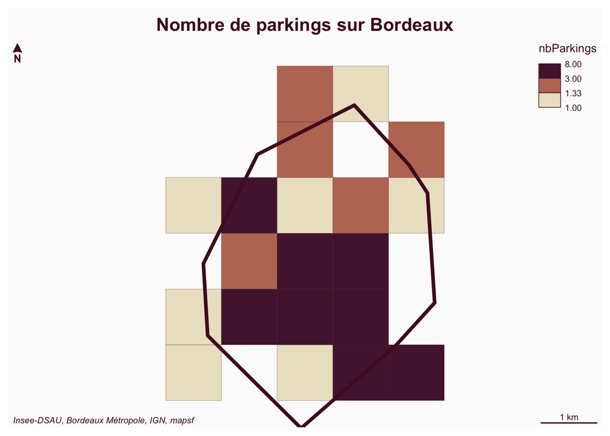

## Partie 2.2 : Lissage de la densité des parkings

**Note**Exercice 6**

1. Créer un “buffer” du centre-ville de Bordeaux (avec une marge de 3 000 mètres autour) et enregistrer le résultat dans `centreBdxBuffer`.
2. Représenter le centre de Bordeaux et son buffer avec la librairie `mapview`
3. Sélectionner les parkings positionnés dans cette zone tampon et enregistrer la nouvelle table `parkingsBuff`.

**Attention :** cette nouvelle table doit garder des colonnes x et y en vue du carroyage.

**Tip**

1. Utiliser la fonction `st_buffer`

**Tip**

3. Utiliser la fonction `st_join`

**Solution**Solution 6**

```r
# 1. Création d'un buffer autour du territoire
marge <- 3000
centreBdxBuffer <- st_buffer(centreBdx, dist = marge)

# 2. Cartographie avec mapview
mapview(centreBdxBuffer, col.region= "gray") + mapview(centreBdx)

# 3. Réduire la base aux seules observations dans le territoire
parkingsBuff <- st_join(sfParkings, centreBdxBuffer, left = F)
parkingsBuff
```

[interactive chart not shown]

**Note**Exercice 7**

1. Créer une variable `nbObsLisse = 1L` dans `parkingsBuff`. Que représente-t-elle ?
2. Lisser le nombre de parkings dans le buffer du centre-ville de Bordeaux :
   - Avec un rayon de lissage de 1 700 mètres
   - En générant une grille carroyée de 50 mètres de côté
3. Restreindre les carreaux de 50 mètres obtenus aux seuls carreaux intersectant le centre-ville et enregistrer le résultat dans `sfCarLisse`
4. Cartographier le résultat obtenu avec la fonction `generCarte`.
5. [BONUS] Proposer une transformation permettant d’obtenir une densité au km².

**Tip**

2. Utiliser bien sûr la fonction `btb_smooth` !

**Solution**Solution 7**

```r
# 1. Nouvelle variable nbObsLisse
parkingsBuff$nbObsLisse <- 1L
#### C'est une variable de "comptage des observations".

# 2. Lissage
rayon <- 1700 # Rayon de lissage
tcar <-  50 # Taille des carreaux de la grille
sfCarLisse <- btb_smooth(pts = parkingsBuff[, c("nbObsLisse", "x", "y")],
                         sEPSG = "2154",
                         iCellSize = tcar,
                         iBandwidth = rayon)

# 3. Filtrage : ne garder que les carreaux intersectant le centre de Bordeaux
sfCarLisse <- sfCarLisse %>% st_join(centreBdx, left = F)

# 4. Carte lissée avec mapsf
generCarte(sfCar = sfCarLisse, nomvar = "nbObsLisse", nbreaks = 5, zone = centreBdx,
           titre = paste0("Lissage de la densité de parkings avec un rayon de ", rayon, " m"))
```

```r
#5. densité au km2
sfCarLisse$nbObsLisse_km2 <- sfCarLisse$nbObsLisse * ((1000 / tcar) ^ 2)
generCarte(sfCar = sfCarLisse, nomvar = "nbObsLisse_km2", nbreaks = 5, zone = centreBdx,
           titre = paste0("Lissage de la densité (km2) de parkings avec un rayon de ", rayon, " m"))
```

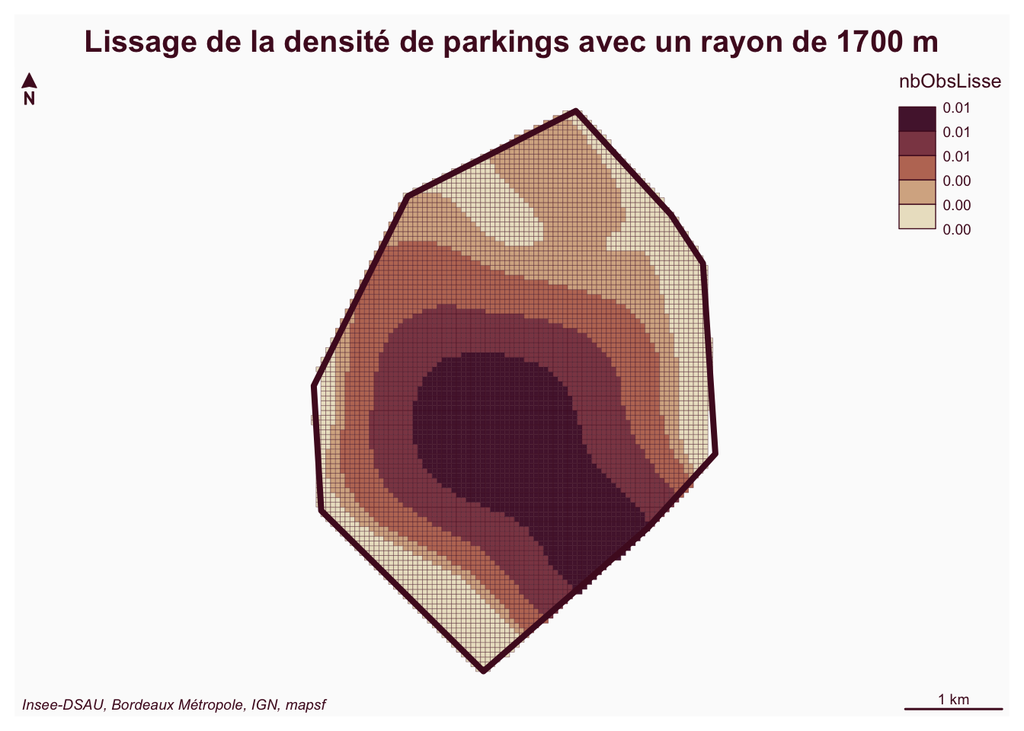

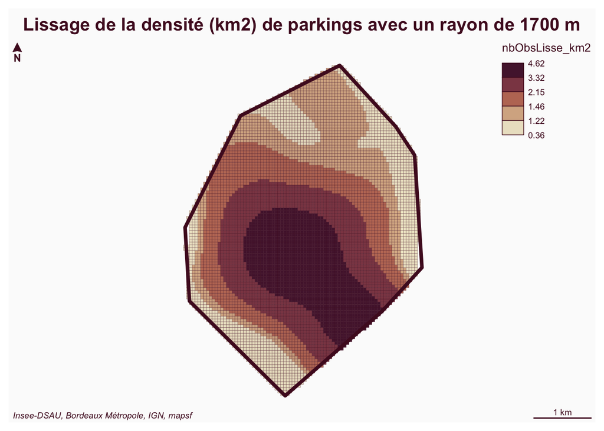

**Note**Exercice 8**

Refaire le lissage avec un rayon de 600 mètres, puis avec un rayon de 3000 mètres. Essayer de créer une fonction générale pour automatiser vos traitements.

**Solution**Solution 8**

```r
lissage_maison <- function(rayon){

  sfCarLisse <- btb_smooth(pts = parkingsBuff[, c("nbObsLisse", "x", "y")],
                           sEPSG = "2154",
                           iCellSize = tcar,
                           iBandwidth = rayon)

  sfCarLisse <- sfCarLisse %>%
    st_join(centreBdx, left = F) %>%
    mutate(nbObsLisse = nbObsLisse * (1000 / tcar) ^ 2)

  generCarte(sfCar = sfCarLisse, nomvar = "nbObsLisse", nbreaks = 5, zone = centreBdx,
             titre = paste0("Lissage de la densité de parkings avec un rayon de ", rayon, " m"))
}

# cartographies :
lissage_maison(600)
```

```r
lissage_maison(3000)
```

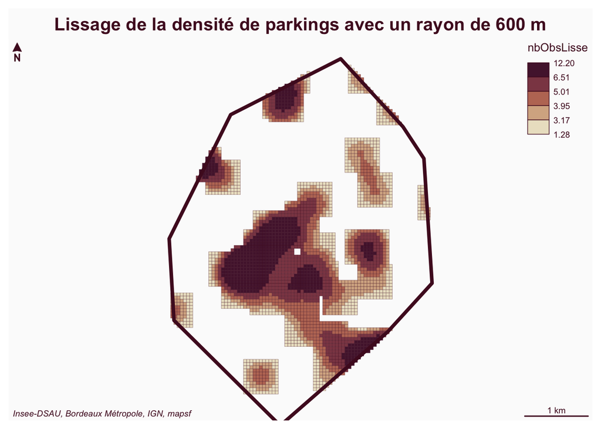

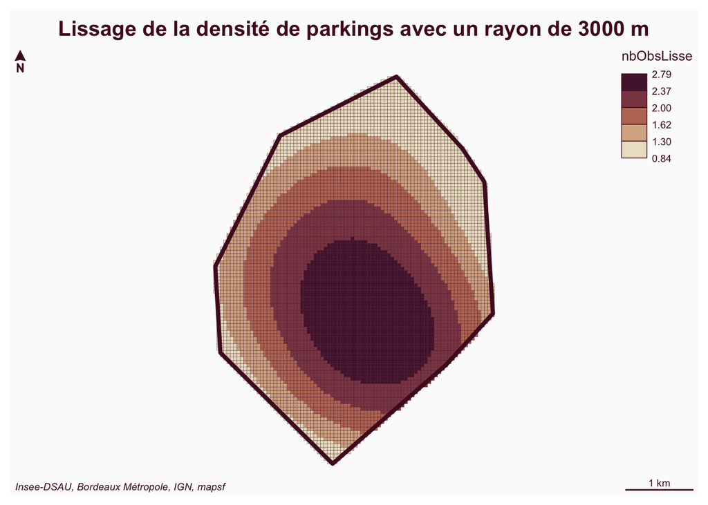

## Partie 2.3 : Lissage du nombre de places de parkings

**Note**Exercice 9**

Lisser le nombre de places de stationnement (variable `np_global`), et non plus le nombre de parkings.

**Remarque :** Pour la suite, toujours prendre un rayon de lissage de 1 700 mètres sauf mention contraire.

**Solution**Solution 9**

```r
rayon <- 1700
sfCarLisse <- btb_smooth(pts = parkingsBuff[,c("np_global", "x", "y")],
                         sEPSG = "2154",
                         iCellSize = tcar,
                         iBandwidth = rayon)

# Filtrage des carreaux lissés dans Bordeaux centre
sfCarLisse <- sfCarLisse %>%
  st_join(centreBdx, left = F) %>%
  mutate(np_global = np_global * (1000 / tcar) ^ 2)

# Carte lissée
generCarte(sfCar = sfCarLisse, nomvar = "np_global", nbreaks = 5, zone = centreBdx,
           titre = "Lissage des places de stationnement")
```

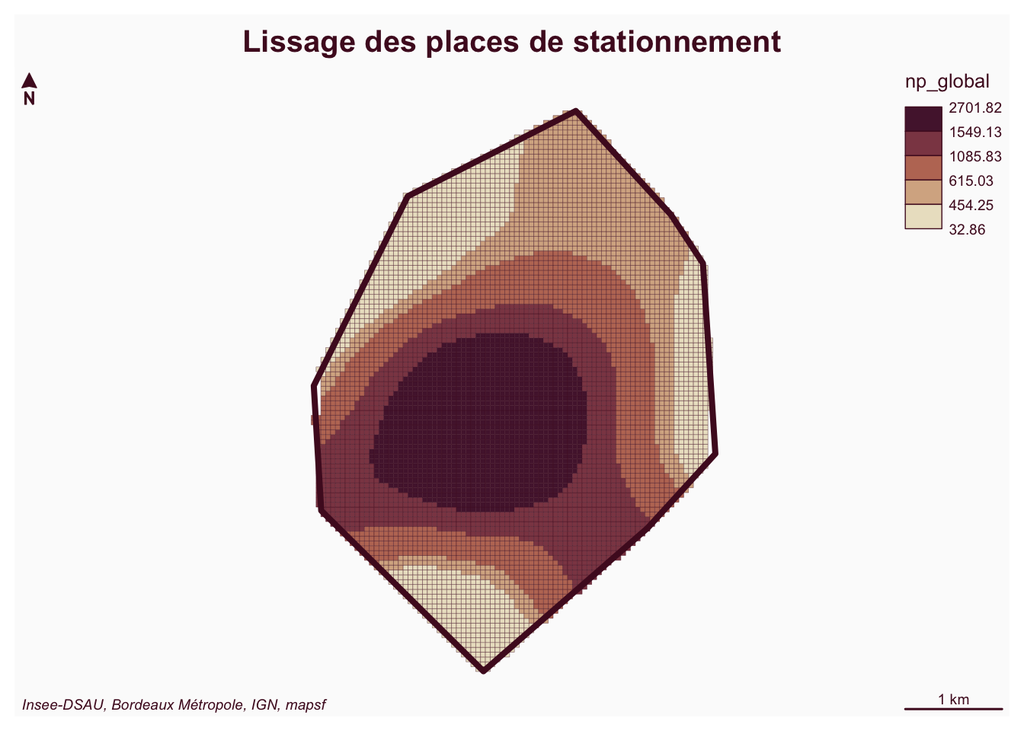

**Note**Exercice 10**

Lisser le nombre de places de stationnement pour les personnes à mobilité réduite (variable `np_pmr`).

**Solution**Solution 10**

```r
sfCarLisse <- btb_smooth(pts = parkingsBuff[,c("np_pmr", "x", "y")],
                         sEPSG = "2154",
                         iCellSize = tcar,
                         iBandwidth = rayon)

# Filtrage des carreaux lissés dans Bordeaux centre
sfCarLisse <- sfCarLisse %>%
  st_join(centreBdx, left = F)%>%
  mutate(np_pmr = np_pmr * (1000 / tcar) ^ 2)

# Carte lissée
generCarte(sfCar = sfCarLisse, nomvar = "np_pmr", nbreaks = 5, zone = centreBdx,
           titre = "Lissage des places de stationnement PMR")
```

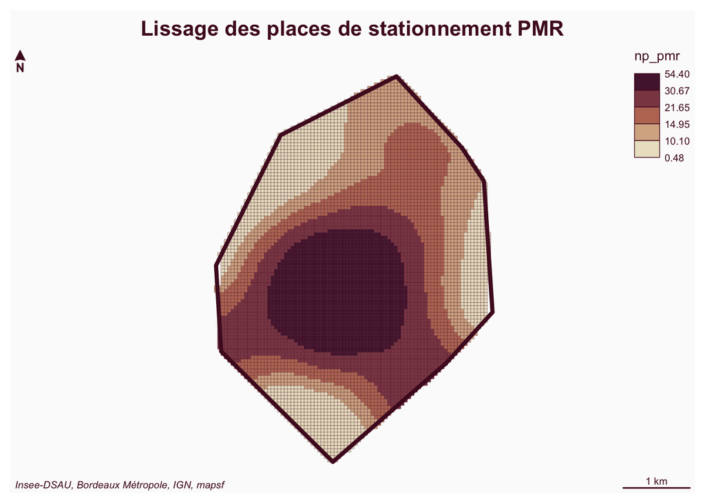

## Partie 2.4 : Lissage de ratios

**Note**Exercice 11**

Lisser le nombre moyen de places de stationnement par parking.

**Tip**

Ne jamais lisser directement le ratio ! On lisse le numérateur et le dénominateur séparément. Puis, on fait le ratio sur les carreaux générés par `btb_smooth`.

**Solution**Solution 11**

```r
sfCarLisse <- btb_smooth(pts = parkingsBuff[, c("nbObsLisse", "np_global", "x", "y")],
                         sEPSG = "2154",
                         iCellSize = tcar,
                         iBandwidth = rayon)

# Création du ratio lissé à partir des numérateur et dénominateur lissés
sfCarLisse <- sfCarLisse %>% mutate(place_par_parking = np_global/nbObsLisse)

sfCarLisse <- sfCarLisse %>% st_join(centreBdx, left = F)
generCarte(sfCar = sfCarLisse, nomvar = "place_par_parking", nbreaks = 5, zone = centreBdx,
           titre = "Lissage du nombre de places par parking")
```

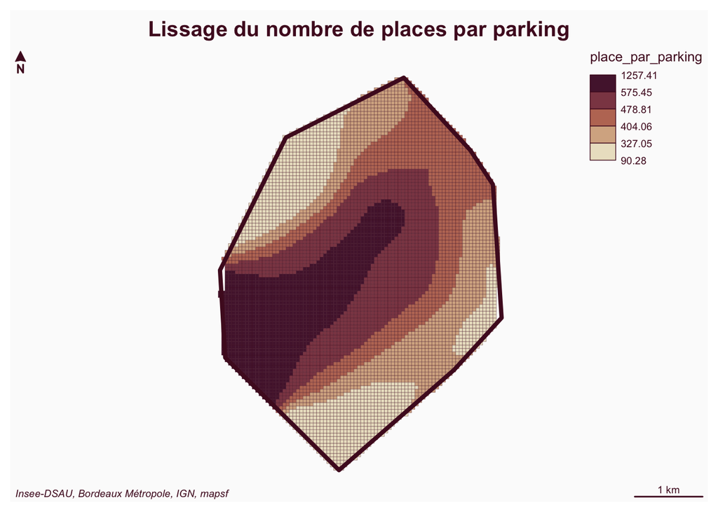

**Note**Exercice 12**

Lisser le taux de places de stationnement pour personnes à mobilité réduite (en %).

**Solution**Solution 12**

```r
sfCarLisse <- btb_smooth(pts = parkingsBuff[, c("np_global", "np_pmr", "x", "y")],
                              sEPSG = "2154",
                              iCellSize = tcar,
                              iBandwidth = rayon)
# Création du ratio lissé à partir des numérateur et dénominateur lissés
sfCarLisse$part_pmf <- 100 * sfCarLisse$np_pmr / sfCarLisse$np_global
sfCarLisse <- sfCarLisse %>% st_join(centreBdx, left = F)

generCarte(sfCar = sfCarLisse, nomvar = "part_pmf", nbreaks = 5, zone = centreBdx,
           titre = "Lissage de la part de places PMR")
```

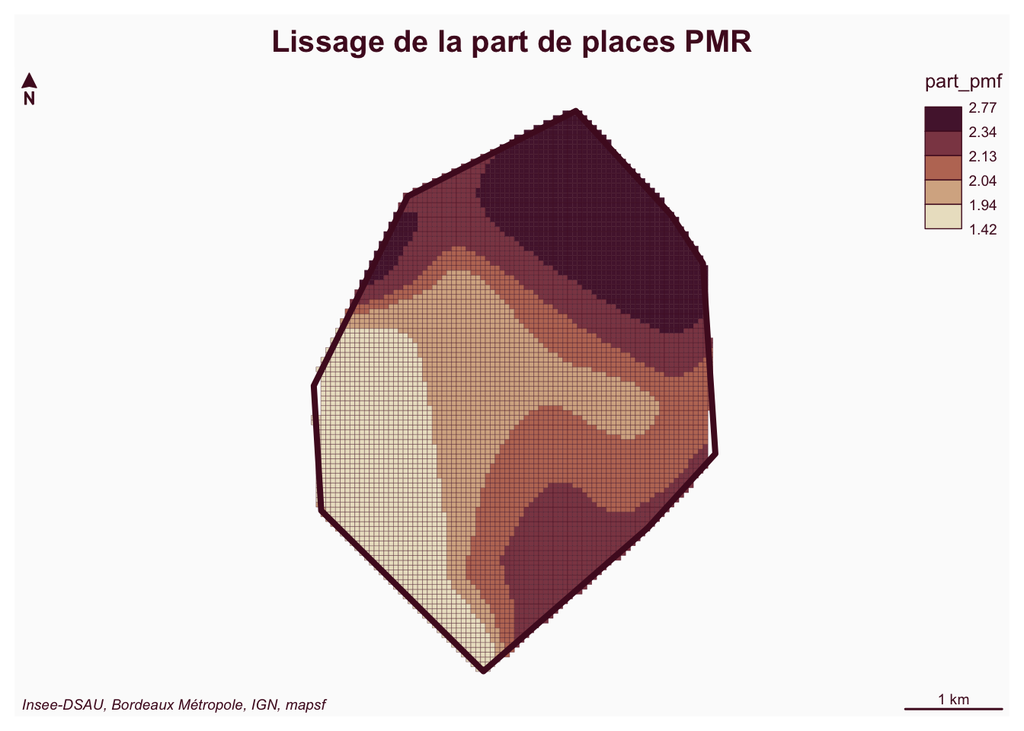

## Partie 2.5 [BONUS] : où trouver des places de parking pas chères ?

**Note**Exercice 13**

Lisser le prix moyen d’une heure de stationnement par parking (sans pondérer par le nombre de places)

**Tip**

On veut lisser le prix d’une heure de stationnement par rapport au nombre de parkings.

**Solution**Solution 13**

```r
sfCarLisse <- btb_smooth(pts = parkingsBuff[, c("nbObsLisse", "th_heur", "x", "y")],
                         sEPSG = "2154",
                         iCellSize = tcar,
                         iBandwidth = rayon)

sfCarLisse$prix_moyen <- sfCarLisse$th_heur / sfCarLisse$nbObsLisse
sfCarLisse <- sfCarLisse %>% st_join(centreBdx, left = F)

generCarte(sfCar = sfCarLisse, nomvar = "prix_moyen", nbreaks = 5, zone = centreBdx,
           titre = "Lissage du prix par parking (sans pondération)")
```

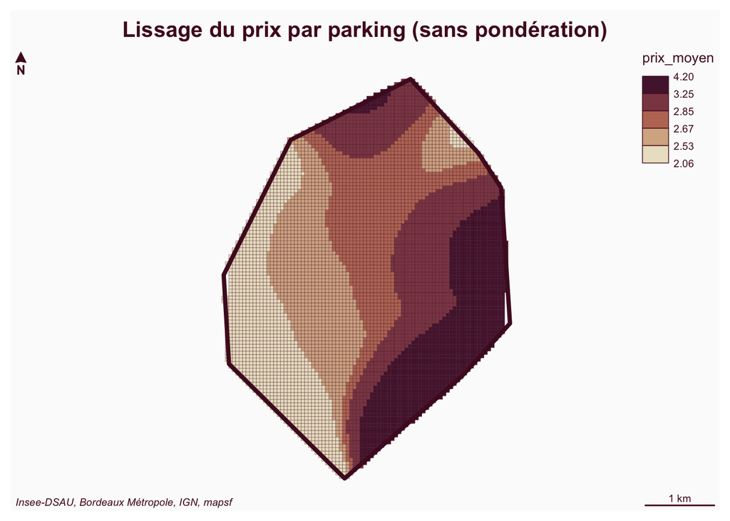

**Note**Exercice 14**

Lisser le prix moyen d’une heure de stationnement (prendre en compte le nombre de places de stationnement par parking).

**Tip**

Pour chaque parking de la base, il faut lisser :

- la multiplication du prix et du nombre de places
- le nombre de places

Puis, faire le ratio pour obtenir le “prix moyen d’une place” lissé.

**Solution**Solution 14**

```r
# Création de la variable "multiplication du prix et du nmbre de places" pour chaque parking
parkingsBuff <- parkingsBuff %>% mutate(prix_x_place = np_global * th_heur)

sfCarLisse <- btb_smooth(pts = parkingsBuff[, c("np_global", "prix_x_place", "x", "y")],
                         sEPSG = "2154",
                         iCellSize = tcar,
                         iBandwidth = rayon)

# Et on rapporte par le nombre de places lissé.
sfCarLisse <- sfCarLisse %>% mutate(prix_moyen_place = prix_x_place / np_global)

sfCarLisse <- sfCarLisse %>% st_join(centreBdx, left = F)

# Carte lissée
generCarte(sfCar = sfCarLisse, nomvar = "prix_moyen_place", nbreaks = 5, zone = centreBdx,
           titre = "Lissage du prix moyen par place de stationnement")
```

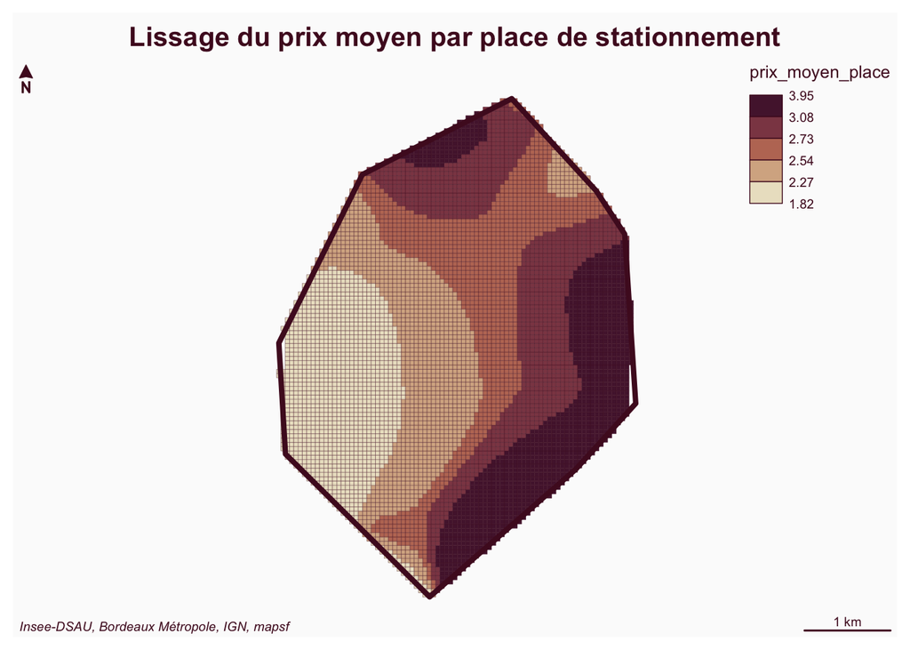

# Phase 3 : Calcul d’indicateurs sur une zone à façon

**Note**Exercice 15**

Combien d’habitants vivent dans le centre de Bordeaux tel que nous l’avons défini ?

Pour répondre à cette question :

1. Comme dans le tutoriel, charger la base des données Filosofi carroyées (grille de 200m) en ne chargeant que les carreaux de la Gironde (département 33) grâce à l’option `query` de `st_read`.
2. Vérifier les projections cartographiques utilisées puis faire une intersection géographique entre les carreaux de la Gironde et le contour géographique du centre de Bordeaux
3. Cartographier avec `mapview` les carreaux du centre de Bordeaux.
4. Calculer le nombre d’habitants grâce à la variable `ind`.

**Solution**Solution 15**

```r
# 1. Chargement des données de Filosofi en Gironde
url_bucket <- "https://minio.lab.sspcloud.fr/projet-formation/r-lissage-spatial/"
object = "carreaux_200m_met.gpkg"

st_read_maison <- function(chemin_tab){
  requete <- "SELECT idcar_200m, lcog_geo, ind, geom
            FROM carreaux_200m_met
            WHERE SUBSTR(lcog_geo, 1, 2) IN ('33')"
  st_read(chemin_tab, query = requete, quiet = TRUE)
}

car33 <-  st_read_maison(paste0(url_bucket, object))

# 2. Vérification de la projection
head(car33)
# projection 2154 (Lambert93)

# Sélection des carreaux intersectant le centre de Bordeaux
carreaux_centreBdx <- car33 %>% st_join(centreBdx, left = F)

# 3. Cartographie des carreaux du centre de Bordeaux
mapview(centreBdx, color = "black", lwd = 6, alpha.regions = 0, legend = F) +
  mapview(carreaux_centreBdx, col.regions = "#ffff00")

# 4. Combien d'habitants dans le centre de Bordeaux ?
cat("Il y a approximativement", sum(carreaux_centreBdx$ind), "habitants dans le centre de Bordeaux")
```

```
Simple feature collection with 6 features and 3 fields
Geometry type: POLYGON
Dimension:     XY
Bounding box:  xmin: 438486.3 ymin: 6350085 xmax: 439499.4 ymax: 6351138
Projected CRS: RGF93 v1 / Lambert-93
                      idcar_200m lcog_geo ind                           geom
1 CRS3035RES200mN2399800E3501000    33095   3 POLYGON ((438504 6350085, 4...
2 CRS3035RES200mN2399800E3501800    33095   1 POLYGON ((439300.3 6350162,...
3 CRS3035RES200mN2400200E3501200    33095   1 POLYGON ((438667.8 6350502,...
4 CRS3035RES200mN2400400E3501400    33095   5 POLYGON ((438849.3 6350721,...
5 CRS3035RES200mN2400400E3501600    33095   4 POLYGON ((439048.4 6350740,...
6 CRS3035RES200mN2400600E3501400    33095   8 POLYGON ((438831.7 6350920,...
```

[interactive chart not shown]

```
Il y a approximativement 137804 habitants dans le centre de Bordeaux
```

**Reproductibilité**

## Footnotes

[^1]: `mapview` est un package de cartographie produisant des résultats proches de `leaflet`. Il est un peu plus rapide d’utilisation quant il s’agit de produire des résultats simples : notamment, il reprojette automatiquement les objets géographiques que vous souhaitez cartographier. Plus d’informations [ici](https://r-spatial.github.io/mapview/).
[^2]: construit manuellement par les auteurs de ce tutoriel en utilisant le [Geoportail](https://www.geoportail.gouv.fr/).